```r
library(biomaRt) #  Load the biomaRt library for accessing biological data through BioMart
library(data.table) # Load the data.table library for efficient data manipulation
library(ggplot2) # Load the ggplot2 library for creating data visualizations
library(readxl) # Load the readxl library for reading Excel files into R
```

```r
setwd("/scratch/silo1/rameez/ldscore/Geneweaver")
```

# Here is an example demonstrating the extraction of genes from the GeneWeaver database.

```r
# Read an Excel file named "Withdrawal Human Orthologs.xlsx" from the specified path
Jason_list <- read_excel("/projects/bga_lab/DATA_REPOSITORIES/COGA_WITHDRAWAL/UM_IMP_RESULTS/MERGED_CLEAN/SmokeScreen/Withdrawal Human Orthologs.xlsx",sheet = 1, skip = 7)
# Convert the read data into a data frame
Jason_list <- as.data.frame(Jason_list)
# Display the first few rows and dimensions of the data frame
head(Jason_list); dim(Jason_list)
# Create a new column named "GENE" containing lowercase versions of values from "Column 2"
Jason_list$GENE <- tolower(Jason_list$'Column 2')
# Extract columns "GENE" and "Hippocampus Alcohol Withdrawal" into a new data frame
J_list_withdrawal <- Jason_list[,c("GENE","Hippocampus Alcohol Withdrawal")]
# Filter rows where the "Hippocampus Alcohol Withdrawal" column is equal to 1
J_list_withdrawal <- J_list_withdrawal[J_list_withdrawal$'Hippocampus Alcohol Withdrawal' == 1,]
# Display the first few rows and dimensions of the filtered data frame
J_list_withdrawal$GENE <- toupper(J_list_withdrawal$GENE )
head(J_list_withdrawal); dim(J_list_withdrawal)
```

A data.frame: 6 × 17

|  | GeneWeaver ID <dbl> | Column 2 <chr> | human_gene_id <chr> | Hippocampus Alcohol Withdrawal <dbl> | Prefrontal cortex and HIC <dbl> | Prefontal cortex HIC <dbl> | EtOH abstinence postchronic WSPR <dbl> | Ventral Striaum SOT vs NOT <dbl> | Hippocampus and alcohol withdrawal <dbl> | Striatum and HIC <dbl> | Striatum and Withdrawal <dbl> | Prefrontal Cortex of C57BL/6J Mice <dbl> | Nucleus Accumbens of C57BL/6J Mice <dbl> | Hippocampus of C57BL/6J Mice <dbl> | UpReg EtOH Withdrawal D2 <dbl> | DwnReg EtOH Withdrawl B6 <dbl> | Sum <dbl> |
| --- | --- | --- | --- | --- | --- | --- | --- | --- | --- | --- | --- | --- | --- | --- | --- | --- | --- |
| 1 | 4475 | Rgs5 | HGNC:10001 | 0 | 0 | 0 | 0 | 0 | 0 | 0 | 0 | 0 | 0 | 1 | 0 | 0 | 1 |
| 2 | 118287 | Rit1 | HGNC:10023 | 1 | 0 | 0 | 0 | 0 | 0 | 0 | 0 | 0 | 0 | 0 | 0 | 0 | 1 |
| 3 | 104584 | Rnase4 | HGNC:10047 | 1 | 0 | 0 | 0 | 0 | 0 | 0 | 0 | 0 | 0 | 0 | 0 | 0 | 1 |
| 4 | 4465 | Rnasel | HGNC:10050 | 0 | 0 | 0 | 0 | 1 | 0 | 0 | 0 | 0 | 0 | 0 | 0 | 0 | 1 |
| 5 | 7196 | Rnf10 | HGNC:10055 | 0 | 0 | 0 | 0 | 0 | 0 | 0 | 0 | 0 | 1 | 0 | 0 | 0 | 1 |
| 6 | 5619 | Bcl7c | HGNC:1006 | 0 | 0 | 0 | 0 | 1 | 0 | 0 | 0 | 0 | 0 | 0 | 0 | 0 | 1 |

1. 3070

2. 17

A data.frame: 6 × 2

|  | GENE <chr> | Hippocampus Alcohol Withdrawal <dbl> |
| --- | --- | --- |
| 2 | RIT1 | 1 |
| 3 | RNASE4 | 1 |
| 17 | RPL10A | 1 |
| 20 | RPL18 | 1 |
| 21 | RPL18A | 1 |
| 22 | RPL27 | 1 |

1. 816

2. 2

#### When uploading data to the LDSC tool, it's important to consider two different data formats. To create these formats, there are two available options that can be helpful.

chr1 10086 10350  
chr1 713633 714148  
chr1 714388 714677  
chr1 754106 754303  
OR  
ENSG00000105605  
ENSG00000169862  
ENSG00000074317  
ENSG00000196361  
ENSG00000221946

### Option #1: Utilize the BioMart packages in R to extract chromosome, start/end positions.

```r
# Define the biomart connection for GRCh37
grch37 = useMart(biomart="ENSEMBL_MART_ENSEMBL", host="grch37.ensembl.org", path="/biomart/martservice", dataset="hsapiens_gene_ensembl")
# Retrieve gene information from GRCh37 biomart
gene_37 <-getBM(attributes=c('ensembl_gene_id',"ensembl_gene_id_version","hgnc_symbol",'chromosome_name','start_position','end_position'), mart = grch37)
# Filter genes located on chromosomes 1 to 22
gene_37 <- gene_37[gene_37$chromosome_name == 1 | gene_37$chromosome_name == 2 | gene_37$chromosome_name == 3 | gene_37$chromosome_name == 4 |
				  gene_37$chromosome_name == 5 | gene_37$chromosome_name == 6 | gene_37$chromosome_name == 7 | gene_37$chromosome_name == 8  |
				  gene_37$chromosome_name == 9 | gene_37$chromosome_name == 10 | gene_37$chromosome_name == 11 | gene_37$chromosome_name == 12  |
				  gene_37$chromosome_name == 13 | gene_37$chromosome_name == 14 | gene_37$chromosome_name == 15 | gene_37$chromosome_name == 16  |
				  gene_37$chromosome_name == 17 | gene_37$chromosome_name == 18 | gene_37$chromosome_name == 19 | gene_37$chromosome_name == 20  |
				  gene_37$chromosome_name == 21 | gene_37$chromosome_name == 22 ,]
# Convert the result to a data frame
gene_37 <- as.data.frame(gene_37)
# Display the first few rows and dimensions of the data frame
head(gene_37); dim(gene_37)
```

A data.frame: 6 × 6

|  | ensembl_gene_id <chr> | ensembl_gene_id_version <chr> | hgnc_symbol <chr> | chromosome_name <chr> | start_position <int> | end_position <int> |
| --- | --- | --- | --- | --- | --- | --- |
| 2 | ENSG00000223116 | ENSG00000223116.1 |  | 13 | 23551994 | 23552136 |
| 3 | ENSG00000233440 | ENSG00000233440.2 | HMGA1P6 | 13 | 23708313 | 23708703 |
| 4 | ENSG00000207157 | ENSG00000207157.1 | RNY3P4 | 13 | 23726725 | 23726825 |
| 5 | ENSG00000229483 | ENSG00000229483.2 | LINC00362 | 13 | 23743974 | 23744736 |
| 6 | ENSG00000252952 | ENSG00000252952.1 | RNU6-58P | 13 | 23791571 | 23791673 |
| 7 | ENSG00000235205 | ENSG00000235205.1 | TATDN2P3 | 13 | 23817659 | 23821323 |

1. 54921

2. 6

```r
# Merge the J_list_withdrawal and gene_37 data frames by the 'GENE' column without sorting
gene_37_J_list_withdrawal <- merge(J_list_withdrawal,gene_37,by.x = "GENE", by.y = "hgnc_symbol", sort = FALSE)
# Display the first few rows and dimensions of the merged data frame
head(gene_37_J_list_withdrawal); dim(gene_37_J_list_withdrawal)
```

A data.frame: 6 × 7

|  | GENE <chr> | Hippocampus Alcohol Withdrawal <dbl> | ensembl_gene_id <chr> | ensembl_gene_id_version <chr> | chromosome_name <chr> | start_position <int> | end_position <int> |
| --- | --- | --- | --- | --- | --- | --- | --- |
| 1 | RIT1 | 1 | ENSG00000143622 | ENSG00000143622.6 | 1 | 155867599 | 155881195 |
| 2 | RNASE4 | 1 | ENSG00000258818 | ENSG00000258818.2 | 14 | 21152259 | 21168761 |
| 3 | RPL10A | 1 | ENSG00000198755 | ENSG00000198755.6 | 6 | 35436185 | 35438562 |
| 4 | RPL18 | 1 | ENSG00000063177 | ENSG00000063177.8 | 19 | 49118585 | 49122793 |
| 5 | RPL18A | 1 | ENSG00000105640 | ENSG00000105640.8 | 19 | 17970685 | 17974962 |
| 6 | RPL27 | 1 | ENSG00000131469 | ENSG00000131469.8 | 17 | 41150290 | 41154976 |

1. 724

2. 7

```r
# Select specific columns 'chromosome_name', 'start_position', and 'end_position' from gene_37_J_list_withdrawal
gene_37_J_list_withdrawal_sub <- gene_37_J_list_withdrawal[,c("chromosome_name","start_position","end_position")]
# Prepend "chr" to the 'chromosome_name' column values
gene_37_J_list_withdrawal_sub$chromosome_name <- paste("chr",gene_37_J_list_withdrawal_sub$chromosome_name,sep = "")
# Rename the column names to 'CHR', 'START', and 'END'
colnames(gene_37_J_list_withdrawal_sub) <- c("CHR","START","END")
# Display the first few rows and dimensions of the subsetted data frame
head(gene_37_J_list_withdrawal_sub); dim(gene_37_J_list_withdrawal_sub)
# Write the subsetted data frame to a tab-separated text file named "J_list_withdrawal_geneset.txt"
fwrite(gene_37_J_list_withdrawal_sub,"J_list_withdrawal_geneset.txt",sep = "\t", col.names = FALSE)
```

A data.frame: 6 × 3

|  | CHR <chr> | START <int> | END <int> |
| --- | --- | --- | --- |
| 1 | chr1 | 155867599 | 155881195 |
| 2 | chr14 | 21152259 | 21168761 |
| 3 | chr6 | 35436185 | 35438562 |
| 4 | chr19 | 49118585 | 49122793 |
| 5 | chr19 | 17970685 | 17974962 |
| 6 | chr17 | 41150290 | 41154976 |

1. 724

2. 3

### Option #2: Use the link (https://biit.cs.ut.ee/gprofiler/convert) to extract the ENSC format.

```r
# Write the first column of the J_list_withdrawal dataframe to a text file
# The column contains gene names
# The file will be named "J_list_withdrawal_gene.txt"
# The 'col.names = F' argument ensures column names are not included in the output file
fwrite(as.data.frame(J_list_withdrawal[,1]),"J_list_withdrawal_gene.txt", col.names = F)
```

[figure not shown]

```r
# This is how the genelist will look like in the "J_list_withdrawal_gene.txt" file.
IRdisplay::display_png(file = "gene_list.png")
```

[figure not shown]

```r
# Please select all genes, copy them, and paste them into the g:Profiler link. After that, click "Run query."
IRdisplay::display_png(file = "gprofiler.png")
```

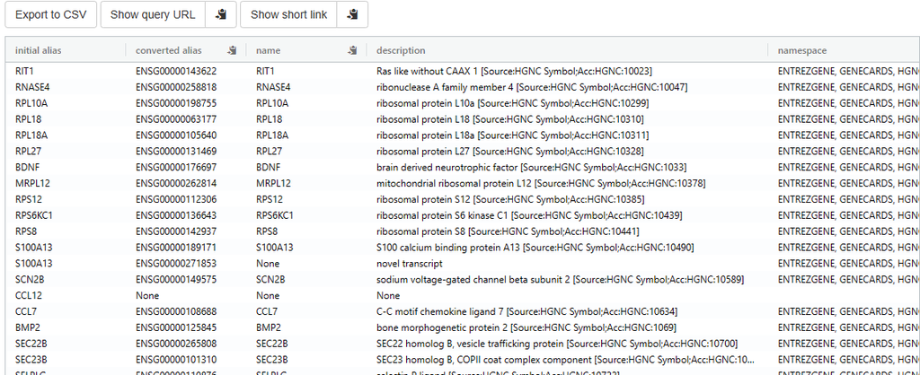

```r
# After a few seconds, you will see the results. Please export them as a CSV file.
IRdisplay::display_png(file = "output.png")
```

```r
# When you export the CSV file, you can load the dataframe into R for further dataset filtering.
# Read the data from the CSV file "gProfiler_hsapiens_7-24-2023_12-41-16 PM.csv" into a dataframe
J_list_withdrawal_ENSG <- fread("gProfiler_hsapiens_7-24-2023_12-41-16 PM.csv")
# Display the first few rows of the dataframe and its dimensions
head(J_list_withdrawal_ENSG); dim(J_list_withdrawal_ENSG)
# Write the second column of the J_list_withdrawal_ENSG dataframe to a text file
# The file will be named "J_list_withdrawal_ENSG.txt"
# The 'col.names = F' argument ensures column names are not included in the output file
fwrite(as.data.frame(J_list_withdrawal_ENSG[,2]),"J_list_withdrawal_ENSG.txt", col.names = F)
```

A data.table: 6 × 5

| initial_alias <chr> | converted_alias <chr> | name <chr> | description <chr> | namespace <chr> |
| --- | --- | --- | --- | --- |
| RIT1 | ENSG00000143622 | RIT1 | Ras like without CAAX 1 [Source:HGNC Symbol;Acc:HGNC:10023] | ENTREZGENE,GENECARDS,HGNC,UNIPROT_GN,WIKIGENE |
| RNASE4 | ENSG00000258818 | RNASE4 | ribonuclease A family member 4 [Source:HGNC Symbol;Acc:HGNC:10047] | ENTREZGENE,GENECARDS,HGNC,UNIPROT_GN,WIKIGENE |
| RPL10A | ENSG00000198755 | RPL10A | ribosomal protein L10a [Source:HGNC Symbol;Acc:HGNC:10299] | ENTREZGENE,GENECARDS,HGNC,UNIPROT_GN,WIKIGENE |
| RPL18 | ENSG00000063177 | RPL18 | ribosomal protein L18 [Source:HGNC Symbol;Acc:HGNC:10310] | ENTREZGENE,GENECARDS,HGNC,UNIPROT_GN,WIKIGENE |
| RPL18A | ENSG00000105640 | RPL18A | ribosomal protein L18a [Source:HGNC Symbol;Acc:HGNC:10311] | ENTREZGENE,GENECARDS,HGNC,UNIPROT_GN,WIKIGENE |
| RPL27 | ENSG00000131469 | RPL27 | ribosomal protein L27 [Source:HGNC Symbol;Acc:HGNC:10328] | ENTREZGENE,GENECARDS,HGNC,UNIPROT_GN,WIKIGENE |

1. 818

2. 5

# Summary Statistics

```r
sum_stat_ea <- fread("/projects/bga_lab/DATA_REPOSITORIES/COGA_WITHDRAWAL/UM_IMP_RESULTS/MERGED_CLEAN_V2/update_result/ea_sub/MLMA/COGA_factor_res_age_sex_PC14_cov_cohort_mlma.mlma")
sum_stat_ea <- as.data.frame(sum_stat_ea)
sum_stat_ea <- sum_stat_ea[order(sum_stat_ea$p),]
head(sum_stat_ea); dim(sum_stat_ea)
```

A data.frame: 6 × 9

|  | Chr <int> | SNP <chr> | bp <int> | A1 <chr> | A2 <chr> | Freq <dbl> | b <dbl> | se <dbl> | p <dbl> |
| --- | --- | --- | --- | --- | --- | --- | --- | --- | --- |
| 6217096 | 16 | 16:70983413 | 70983413 | C | T | 0.0572222 | 0.252561 | 0.0434871 | 6.33316e-09 |
| 3642647 | 8 | 8:13454638 | 13454638 | C | T | 0.2520370 | 0.122535 | 0.0237671 | 2.52755e-07 |
| 3642637 | 8 | 8:13452449 | 13452449 | C | T | 0.2500000 | 0.122421 | 0.0238138 | 2.73638e-07 |
| 6217074 | 16 | 16:70930637 | 70930637 | C | T | 0.0543519 | 0.230162 | 0.0448257 | 2.82741e-07 |
| 6216890 | 16 | 16:70769812 | 70769812 | A | G | 0.0562037 | 0.226399 | 0.0444735 | 3.56828e-07 |
| 6217060 | 16 | 16:70901510 | 70901510 | C | T | 0.0561111 | 0.222192 | 0.0442681 | 5.18775e-07 |

1. 7186272

2. 9

```r
# We are attempting to convert chromosome:position (chr:pos) to rsID
rs <- fread("/projects/bga_lab/DATA_REPOSITORIES/IMP_PIPELINE_FILES/chr_pos_rs.txt",header  = FALSE)
rs <- as.data.frame(rs);
head(rs); dim(rs)
```

A data.frame: 6 × 4

|  | V1 <int> | V2 <int> | V3 <chr> | V4 <chr> |
| --- | --- | --- | --- | --- |
| 1 | 1 | 10352 | rs145072688 | 1:10352 |
| 2 | 1 | 10616 | rs376342519 | 1:10616 |
| 3 | 1 | 13116 | rs201725126 | 1:13116 |
| 4 | 1 | 13118 | rs200579949 | 1:13118 |
| 5 | 1 | 14930 | rs75454623 | 1:14930 |
| 6 | 1 | 14933 | rs199856693 | 1:14933 |

1. 32165555

2. 4

```r
# Merge sum_stat_ea with rs by matching "SNP" in sum_stat_ea with "V4" in rs
sum_stat_ea_rs <- merge(sum_stat_ea,rs, by.x = "SNP", by.y = "V4", sort = FALSE)
# Remove duplicated rows based on "SNP" column in the merged dataset
sum_stat_ea_rs <- sum_stat_ea_rs[!duplicated(sum_stat_ea_rs$SNP),]
# Select specific columns from the merged dataset: "V3", "A1", "A2", and "p"
sum_stat_ea_rs_sub <- sum_stat_ea_rs[,c("V3","A1","A2","p")]
# Add a new column "N" with a constant value of 7320
sum_stat_ea_rs_sub$N <- 7320
# Rename the first four columns to "SNP", "Allele1", "Allele2", and "p"
colnames(sum_stat_ea_rs_sub)[1:4] <- c("SNP","Allele1","Allele2","p")
head(sum_stat_ea_rs_sub); dim(sum_stat_ea_rs_sub)
# Write the subsetted dataset to a gzipped text file with tab-separated values
fwrite(as.data.frame(sum_stat_ea_rs_sub),"J_list_withdrawal_sumstat.txt.gz", sep = "\t")
```

A data.frame: 6 × 5

|  | SNP <chr> | Allele1 <chr> | Allele2 <chr> | p <dbl> | N <dbl> |
| --- | --- | --- | --- | --- | --- |
| 1 | rs145973320 | C | T | 6.33316e-09 | 7320 |
| 2 | rs1481592 | C | T | 2.52755e-07 | 7320 |
| 3 | rs12677258 | C | T | 2.73638e-07 | 7320 |
| 4 | rs62048007 | A | G | 3.56828e-07 | 7320 |
| 5 | rs115986303 | C | T | 5.18775e-07 | 7320 |
| 6 | rs7828829 | G | A | 5.82773e-07 | 7320 |

1. 7158432

2. 5

# Heritability Enrichment using the LDSC tool

### Link : http://34.122.49.0/analysis.html

#### When you filter and save your gene list using either option, please upload the file

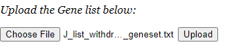

```r
IRdisplay::display_png(file = "upload_gene.png")
```

#### After uploading the file, a Job ID will be generated. Please save this ID and use it in the following link:

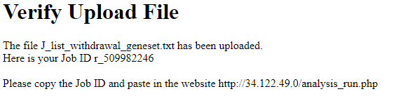

```r
IRdisplay::display_png(file = "verify_gene.png")
```

#### Enter your saved Job ID along with the names of your gene files.

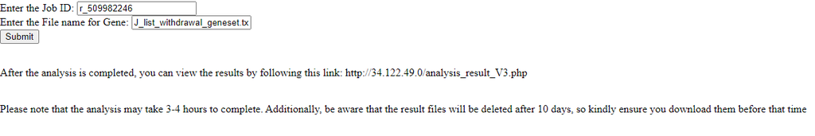

```r
IRdisplay::display_png(file = "analysis_id.png")
```

#### Once you submit, wait for a few hours, and then open the link to enter your Job ID and view your results

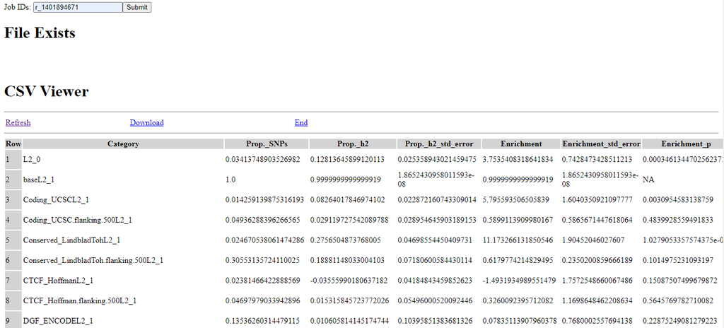

```r
IRdisplay::display_png(file = "enrichment_result.png")
```